# 02 — Dimensões Vetoriais: 384 vs 768 vs 1024

## O que é uma "dimensão"?

Um embedding é basicamente uma lista de números. O número de elementos dessa lista é o que chamamos de **dimensão**.

> **Coordenadas geográficas** usam 2 dimensões (latitude + longitude) para localizar qualquer ponto na Terra. **Embeddings** usam centenas de dimensões para localizar qualquer texto num "espaço de significados".

Você não consegue interpretar o que significa o número na posição 42 ou na posição 137 — o modelo aprendeu essas representações automaticamente durante o treinamento. O que importa é que, coletivamente, esses números capturam o **significado** do texto de forma que textos parecidos ficam próximos nesse espaço.

## Por que diferentes modelos têm dimensões diferentes?

| Dimensões | Intuição |
| --- | --- |
| **Poucas (128–384)** | Menos "slots" pra guardar nuances. Mais rápido, menor uso de memória. Boa para casos simples. |
| **Médias (768)** | Equilíbrio entre qualidade e custo. Padrão da maioria dos modelos BERT. |
| **Muitas (1024–3072)** | Mais "slots" para capturar nuances sutis. Mais lento, mais memória. Melhor qualidade em tarefas difíceis. |

Neste notebook você vai ver **na prática** o que isso significa em termos de memória, velocidade e qualidade.

```python
import numpy as np
import time
import sys
import pandas as pd
import matplotlib.pyplot as plt
import matplotlib.ticker as ticker
from sentence_transformers import SentenceTransformer

# Modelos de diferentes dimensões
MODELS = {
    "all-MiniLM-L6-v2": {"dims": 384, "size_mb": 22, "params": "22M"},
    "all-mpnet-base-v2": {"dims": 768, "size_mb": 420, "params": "110M"},
    # Descomente se tiver memória suficiente (~1.3GB):
    # "all-roberta-large-v1": {"dims": 1024, "size_mb": 1300, "params": "355M"},
}

print("Modelos que vamos comparar:")
for name, info in MODELS.items():
    print(f"  {name}: {info['dims']}d | ~{info['size_mb']}MB | {info['params']} params")
```

```
Modelos que vamos comparar:
  all-MiniLM-L6-v2: 384d | ~22MB | 22M params
  all-mpnet-base-v2: 768d | ~420MB | 110M params
```

## 2.1 Uso de Memória por Dimensão

Antes de tudo, um cálculo simples mas importante.

A tabela abaixo mostra o custo real por escala:

```python
def calcular_memoria(n_vetores, dimensoes, dtype_bytes=4):
    """Calcula uso de memória em GB."""
    return (n_vetores * dimensoes * dtype_bytes) / (1024**3)

scenarios = [
    ("1K docs", 1_000),
    ("10K docs", 10_000),
    ("100K docs", 100_000),
    ("1M docs", 1_000_000),
    ("10M docs", 10_000_000),
]

dimensoes_list = [128, 384, 768, 1024, 1536, 3072]

rows = []
for label, n in scenarios:
    row = {"Escala": label}
    for d in dimensoes_list:
        gb = calcular_memoria(n, d)
        row[f"{d}d"] = f"{gb*1024:.1f}MB" if gb < 1 else f"{gb:.2f}GB"
    rows.append(row)

df = pd.DataFrame(rows).set_index("Escala")
print("Uso de memória (float32) por escala e dimensão:\n")
print(df.to_string())

print("\n💡 Observações:")
print("  1M docs a 768d (MPNet) = 3.07GB — cabe num servidor moderno")
print("  1M docs a 3072d (OpenAI large) = 12.3GB — requer hardware dedicado")
print("  10M docs a 1536d (GPT ada) = 61.4GB — precisa de quantização!")
```

```
Uso de memória (float32) por escala e dimensão:

              128d     384d     768d    1024d    1536d     3072d
Escala
1K docs      0.5MB    1.5MB    2.9MB    3.9MB    5.9MB    11.7MB
10K docs     4.9MB   14.6MB   29.3MB   39.1MB   58.6MB   117.2MB
100K docs   48.8MB  146.5MB  293.0MB  390.6MB  585.9MB    1.14GB
1M docs    488.3MB   1.43GB   2.86GB   3.81GB   5.72GB   11.44GB
10M docs    4.77GB  14.31GB  28.61GB  38.15GB  57.22GB  114.44GB

💡 Observações:
  1M docs a 768d (MPNet) = 3.07GB — cabe num servidor moderno
  1M docs a 3072d (OpenAI large) = 12.3GB — requer hardware dedicado
  10M docs a 1536d (GPT ada) = 61.4GB — precisa de quantização!
```

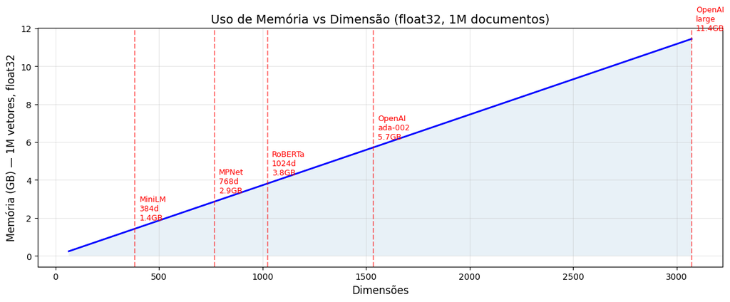

```python
# Visualização: crescimento de memória por dimensão
n_vetores = 1_000_000  # 1 milhão de documentos
dims_range = range(64, 3073, 64)
memoria_gb = [calcular_memoria(n_vetores, d) for d in dims_range]

fig, ax = plt.subplots(figsize=(12, 5))
ax.plot(dims_range, memoria_gb, 'b-', linewidth=2)
ax.fill_between(dims_range, memoria_gb, alpha=0.1)

# Marcar modelos conhecidos
marcadores = {384: "MiniLM\n384d", 768: "MPNet\n768d",
              1024: "RoBERTa\n1024d", 1536: "OpenAI\nada-002", 3072: "OpenAI\nlarge"}
for dim, label in marcadores.items():
    mem = calcular_memoria(n_vetores, dim)
    ax.axvline(x=dim, color='red', linestyle='--', alpha=0.5)
    ax.annotate(f"{label}\n{mem:.1f}GB", (dim, mem),
                textcoords="offset points", xytext=(5, 10), fontsize=9, color='red')

ax.set_xlabel("Dimensões", fontsize=12)
ax.set_ylabel("Memória (GB) — 1M vetores, float32", fontsize=12)
ax.set_title("Uso de Memória vs Dimensão (float32, 1M documentos)", fontsize=14)
ax.grid(True, alpha=0.3)
plt.tight_layout()
plt.show()
```

## 2.2 Benchmark: Velocidade de Embedding

Mais dimensões = mais parâmetros no modelo = mais computação pra gerar cada vetor.

Isso importa em dois cenários:

- **Indexação**: quando você precisa gerar embeddings para toda a sua base de documentos (pode ser milhões)
- **Busca em tempo real**: quando o usuário digita uma query e você precisa embeddar em < 100ms

Vamos medir quantos textos por segundo cada modelo consegue processar.

> **Nota:** esses números variam muito dependendo do hardware (CPU vs GPU) e tamanho do batch. O importante aqui é ver a **diferença relativa** entre os modelos.

```python
# Gerar textos de teste
import random

templates = [
    "A inteligência artificial está transformando {setor}.",
    "O modelo de linguagem {nome} foi treinado com {n} bilhões de tokens.",
    "Embeddings de {d} dimensões são usados em {app}.",
    "A empresa {empresa} anunciou novos investimentos em {tech}.",
]

fills = {
    "setor": ["saúde", "educação", "finanças", "varejo"],
    "nome": ["GPT-4", "Claude", "Gemini", "Llama"],
    "n": ["1", "10", "100", "1000"],
    "d": ["384", "768", "1024", "1536"],
    "app": ["busca semântica", "RAG", "recomendação"],
    "empresa": ["Google", "Microsoft", "Anthropic", "Meta"],
    "tech": ["LLMs", "RAG", "vector databases"],
}

random.seed(42)
test_texts = []
for _ in range(500):
    template = random.choice(templates)
    for key, options in fills.items():
        template = template.replace("{" + key + "}", random.choice(options))
    test_texts.append(template)

print(f"Gerados {len(test_texts)} textos de teste")
print(f"Exemplos: {test_texts[:2]}")
```

```
Gerados 500 textos de teste
Exemplos: ['A inteligência artificial está transformando saúde.', 'A inteligência artificial está transformando varejo.']
```

```python
benchmark_results = {}

for model_name, info in MODELS.items():
    print(f"\nCarregando {model_name}...")
    m = SentenceTransformer(model_name)

    # Warm-up
    _ = m.encode(["warm up"])

    # Benchmark
    start = time.perf_counter()
    embs = m.encode(test_texts, batch_size=32, show_progress_bar=False)
    elapsed = time.perf_counter() - start

    texts_per_sec = len(test_texts) / elapsed
    memory_per_1m = calcular_memoria(1_000_000, info['dims'])

    benchmark_results[model_name] = {
        "dims": info['dims'],
        "texts_per_sec": texts_per_sec,
        "total_time_s": elapsed,
        "memory_1m_gb": memory_per_1m,
    }

    print(f"  ✅ {info['dims']}d | {texts_per_sec:.0f} textos/s | {memory_per_1m:.2f}GB/1M vetores")
    del m  # liberar memória
```

```
Carregando all-MiniLM-L6-v2...
```

```
  ✅ 384d | 755 textos/s | 1.43GB/1M vetores

Carregando all-mpnet-base-v2...
```

```
  ✅ 768d | 122 textos/s | 2.86GB/1M vetores
```

```python
# Tabela resumo
df_bench = pd.DataFrame(benchmark_results).T
df_bench["texts_per_sec"] = df_bench["texts_per_sec"].astype(float).round(0)
df_bench["memory_1m_gb"] = df_bench["memory_1m_gb"].astype(float).round(2)

# Normalizar em relação ao MiniLM
baseline_speed = df_bench.loc["all-MiniLM-L6-v2", "texts_per_sec"]
df_bench["speed_relative"] = (df_bench["texts_per_sec"] / baseline_speed).round(2)

print("\n📊 Benchmark de Velocidade:\n")
print(df_bench[["dims", "texts_per_sec", "speed_relative", "memory_1m_gb"]].to_string())
print("\n(speed_relative: 1.0 = mesmo que MiniLM, 0.5 = metade da velocidade)")
```

```
📊 Benchmark de Velocidade:

                    dims  texts_per_sec  speed_relative  memory_1m_gb
all-MiniLM-L6-v2   384.0          755.0            1.00          1.43
all-mpnet-base-v2  768.0          122.0            0.16          2.86

(speed_relative: 1.0 = mesmo que MiniLM, 0.5 = metade da velocidade)
```

## 2.3 Qualidade Semântica: Mais Dimensões = Melhor?

Memória e velocidade são fáceis de medir. Mas o que realmente importa é: **o modelo com mais dimensões encontra resultados mais relevantes?**

A intuição é que mais dimensões dão ao modelo mais "espaço" para codificar nuances:

- Com 384 dimensões, o modelo talvez não consiga separar bem "backpropagation" de "gradient descent" — ambos são conceitos de ML
- Com 768 dimensões, há mais espaço para capturar que um é um conceito teórico e o outro é um algoritmo

Na prática, a diferença **existe mas é menor do que você esperaria** para a maioria dos casos de uso.

Vamos testar com consultas reais e ver qual modelo encontra o documento mais relevante:

```python
# Conjunto de testes para avaliar qualidade semântica
test_queries = [
    "Como treinar um modelo de machine learning?",
    "Quais são os melhores restaurantes em São Paulo?",
    "O que é backpropagation?",
]

candidate_docs = [
    "O treinamento de redes neurais envolve otimização por gradiente descendente.",  # relevante para query 0 e 2
    "São Paulo tem uma culinária diversificada, com opções japonesas e italianas.",   # relevante para query 1
    "O algoritmo backpropagation calcula gradientes através da regra da cadeia.",    # relevante para query 2
    "A taxa de aprendizado é um hiperparâmetro crucial no treinamento.",             # relevante para query 0
    "O Japão tem culinária tradicional baseada em frutos do mar.",                  # levemente relevante para query 1
    "Python é a linguagem mais usada para ciência de dados.",                       # não muito relevante
]

print("Avaliando qualidade de retrieval por modelo...\n")

for model_name, info in MODELS.items():
    m = SentenceTransformer(model_name)

    query_embs = m.encode(test_queries, normalize_embeddings=True)
    doc_embs = m.encode(candidate_docs, normalize_embeddings=True)

    print(f"\n{'='*60}")
    print(f"Modelo: {model_name} ({info['dims']}d)")
    print(f"{'='*60}")

    for q_idx, query in enumerate(test_queries):
        scores = query_embs[q_idx] @ doc_embs.T
        top_idx = np.argsort(scores)[::-1][0]
        print(f"\nQuery: '{query}'")
        print(f"  Top-1: (score={scores[top_idx]:.3f}) {candidate_docs[top_idx][:70]}...")

    del m
```

```
Avaliando qualidade de retrieval por modelo...
```

```
============================================================
Modelo: all-MiniLM-L6-v2 (384d)
============================================================

Query: 'Como treinar um modelo de machine learning?'
  Top-1: (score=0.434) O algoritmo backpropagation calcula gradientes através da regra da cad...

Query: 'Quais são os melhores restaurantes em São Paulo?'
  Top-1: (score=0.541) São Paulo tem uma culinária diversificada, com opções japonesas e ital...

Query: 'O que é backpropagation?'
  Top-1: (score=0.735) O algoritmo backpropagation calcula gradientes através da regra da cad...
```

```
============================================================
Modelo: all-mpnet-base-v2 (768d)
============================================================

Query: 'Como treinar um modelo de machine learning?'
  Top-1: (score=0.453) O Japão tem culinária tradicional baseada em frutos do mar....

Query: 'Quais são os melhores restaurantes em São Paulo?'
  Top-1: (score=0.601) São Paulo tem uma culinária diversificada, com opções japonesas e ital...

Query: 'O que é backpropagation?'
  Top-1: (score=0.706) O algoritmo backpropagation calcula gradientes através da regra da cad...
```

## 2.4 A Maldição da Dimensionalidade

Existe um fenômeno contraintuitivo chamado **"maldição da dimensionalidade"**:

> Quanto mais dimensões um espaço tem, mais difícil fica distinguir pontos próximos de pontos distantes.

**Por quê?** Imagine você no centro de um círculo 2D. A maioria dos pontos aleatórios fica espalhada pelo círculo. Agora imagine uma esfera 3D — os pontos se concentram na superfície, não no centro. Em 1000 dimensões, praticamente todos os pontos aleatórios ficam numa camada fina perto da superfície — e a distância entre todos eles começa a ser quase igual.

**Consequência para busca vetorial**: se todas as distâncias são parecidas, fica difícil dizer o que é "próximo" e o que é "distante". O índice vetorial perde poder discriminativo.

**Por que isso não destrói os embeddings de texto?**

1. **Os dados não são aleatórios** — textos em português vivem numa região muito específica do espaço, não preenchem todo ele
2. **Sub-variedade de baixa dimensão** — apesar de 768 dimensões existirem, a estrutura real dos dados pode ser muito mais simples (como uma folha dobrada num espaço 3D)
3. **Normalização** — usar vetores na esfera unitária (‖v‖=1) concentra os pontos numa superfície, o que ajuda

O gráfico abaixo mostra esse efeito em vetores **puramente aleatórios** (sem estrutura semântica):

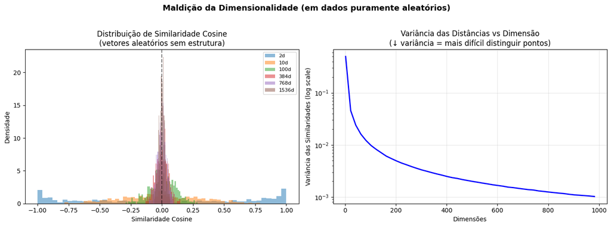

```
💡 Para embeddings REAIS, esse efeito é atenuado porque:
   1. Os dados vivem numa sub-variedade de baixa dimensão
   2. O modelo aprendeu a organizar o espaço semanticamente
```

```python
# Demonstração: concentração de normas em alta dimensão
np.random.seed(42)

n_samples = 10000
dimensoes_demo = [2, 10, 100, 384, 768, 1536]

fig, axes = plt.subplots(1, 2, figsize=(14, 5))

# Plot 1: distribuição de distâncias cosine entre pares aleatórios
for d in dimensoes_demo:
    # Vetores gaussianos aleatórios (sem estrutura semântica)
    vecs = np.random.randn(n_samples, d).astype(np.float32)
    norms = np.linalg.norm(vecs, axis=1, keepdims=True)
    vecs_norm = vecs / norms

    # Amostra de 1000 pares aleatórios
    idx = np.random.choice(n_samples, size=1000, replace=False)
    cos_sims = vecs_norm[idx[:500]] @ vecs_norm[idx[500:]].T
    diag_sims = np.diag(cos_sims)

    axes[0].hist(diag_sims, bins=50, alpha=0.5, density=True, label=f"{d}d")

axes[0].set_title("Distribuição de Similaridade Cosine\n(vetores aleatórios sem estrutura)")
axes[0].set_xlabel("Similaridade Cosine")
axes[0].set_ylabel("Densidade")
axes[0].legend(fontsize=8)
axes[0].axvline(x=0, color='black', linestyle='--', alpha=0.5)

# Plot 2: variância das distâncias por dimensão
all_dims = range(2, 1001, 20)
variances = []
for d in all_dims:
    vecs = np.random.randn(500, d).astype(np.float32)
    vecs = vecs / np.linalg.norm(vecs, axis=1, keepdims=True)
    sims = vecs @ vecs.T
    # Pegar apenas triângulo superior (exceto diagonal)
    mask = np.triu(np.ones_like(sims, dtype=bool), k=1)
    variances.append(np.var(sims[mask]))

axes[1].semilogy(list(all_dims), variances, 'b-', linewidth=2)
axes[1].set_title("Variância das Distâncias vs Dimensão\n(↓ variância = mais difícil distinguir pontos)")
axes[1].set_xlabel("Dimensões")
axes[1].set_ylabel("Variância das Similaridades (log scale)")
axes[1].grid(True, alpha=0.3)

plt.suptitle("Maldição da Dimensionalidade (em dados puramente aleatórios)",
             fontsize=13, fontweight='bold', y=1.02)
plt.tight_layout()
plt.show()

print("\n💡 Para embeddings REAIS, esse efeito é atenuado porque:")
print("   1. Os dados vivem numa sub-variedade de baixa dimensão")
print("   2. O modelo aprendeu a organizar o espaço semanticamente")
```

## Resumo: Quando usar cada dimensão?

| Dimensões | Modelo | Quando usar |
| --- | --- | --- |
| **384** | all-MiniLM-L6-v2 | Prototipagem, tempo real, edge devices |
| **768** | all-mpnet-base-v2 | Produção balanceada, maioria dos casos |
| **1024** | all-roberta-large-v1 | Tarefas exigentes de qualidade |
| **1536** | OpenAI ada-002 | API, sem infra local |
| **3072** | OpenAI text-3-large | State-of-the-art, custo alto |

## Regra prática

> Para a maioria dos sistemas RAG de produção: **768d (all-mpnet-base-v2) é o ponto ideal entre qualidade e custo.**

## Próximos passos

- 03 — Float Types: Comprimir de 3GB para 768MB sem perder qualidade